# Assignment4

Jessica Qian

2026-10-02

```r
library(readxl)
library(fpp2)
getwd()
```

```
## [1] "/Users/jessicaqian/Downloads"
```

```r
retail <- read_excel("/Users/jessicaqian/Downloads/RetailTradeData.xlsx",sheet = "Monthly")
head(retail)
```

```
## # A tibble: 6 × 2
##   `Observation Date`  `Millions of Dollars`
##   <dttm>                              <dbl>
## 1 2016-07-01 00:00:00                315969
## 2 2016-08-01 00:00:00                321639
## 3 2016-09-01 00:00:00                308101
## 4 2016-10-01 00:00:00                314553
## 5 2016-11-01 00:00:00                333195
## 6 2016-12-01 00:00:00                390001
```

```r
names(retail)
```

```
## [1] "Observation Date"    "Millions of Dollars"
```

```r
str(retail)
```

```
## tibble [121 × 2] (S3: tbl_df/tbl/data.frame)
##  $ Observation Date   : POSIXct[1:121], format: "2016-07-01" "2016-08-01" ...
##  $ Millions of Dollars: num [1:121] 315969 321639 308101 314553 333195 ...
```

```r
attributes(retail)
```

```
## $names
## [1] "Observation Date"    "Millions of Dollars"
##
## $row.names
##   [1]   1   2   3   4   5   6   7   8   9  10  11  12  13  14  15  16  17  18
##  [19]  19  20  21  22  23  24  25  26  27  28  29  30  31  32  33  34  35  36
##  [37]  37  38  39  40  41  42  43  44  45  46  47  48  49  50  51  52  53  54
##  [55]  55  56  57  58  59  60  61  62  63  64  65  66  67  68  69  70  71  72
##  [73]  73  74  75  76  77  78  79  80  81  82  83  84  85  86  87  88  89  90
##  [91]  91  92  93  94  95  96  97  98  99 100 101 102 103 104 105 106 107 108
## [109] 109 110 111 112 113 114 115 116 117 118 119 120 121
##
## $class
## [1] "tbl_df"     "tbl"        "data.frame"
```

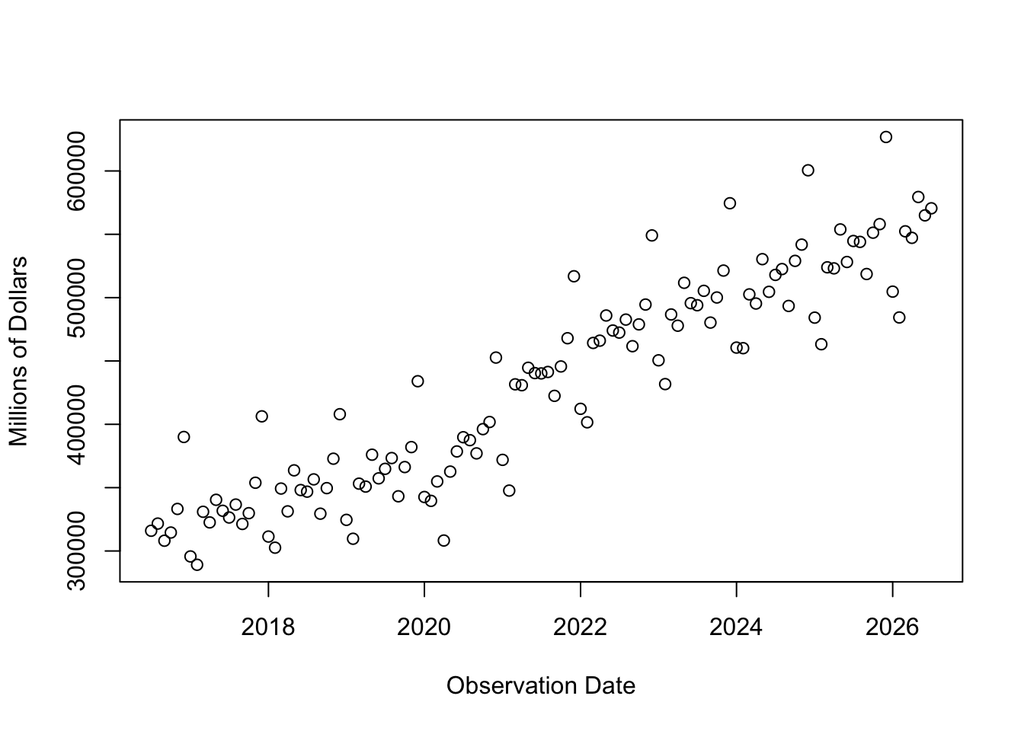

```r
plot(retail)
```

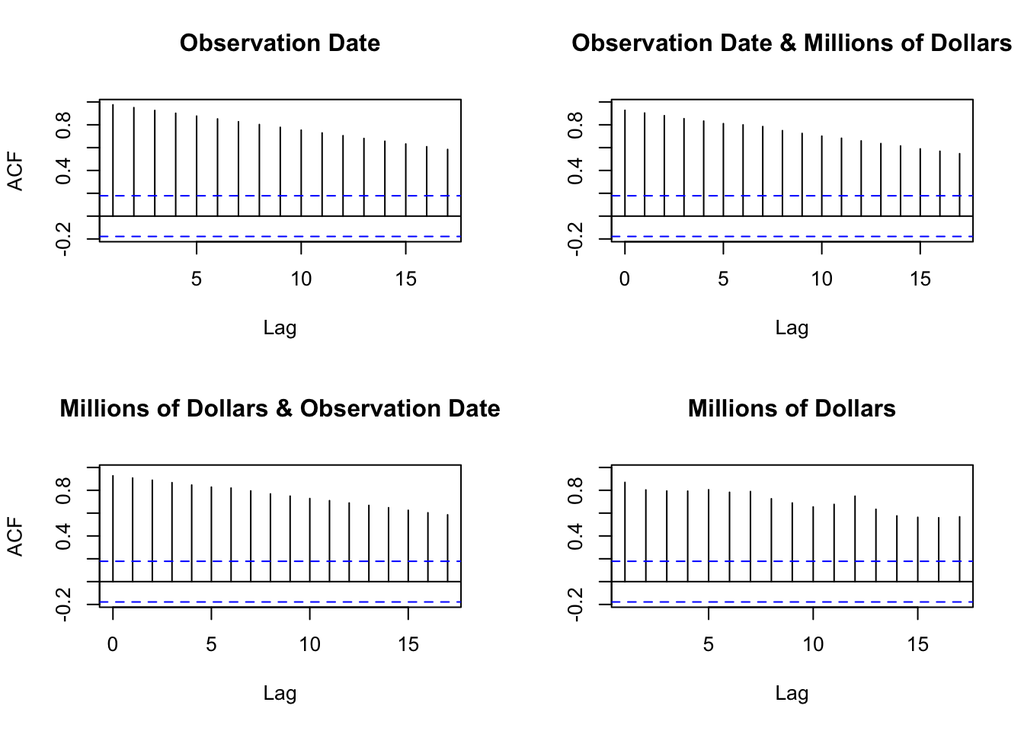

```r
Acf(retail)
```

```r
names(retail)[2] <- "Retail_Sales"
retail_ts <- ts(retail$Retail_Sales,
                start = c(2016, 7),
                frequency = 12)

retail_ts
```

```
##         Jan    Feb    Mar    Apr    May    Jun    Jul    Aug    Sep    Oct
## 2016                                           315969 321639 308101 314553
## 2017 295702 289122 330950 322563 340408 331741 326432 336650 321334 329840
## 2018 311394 302601 349288 331288 363662 348096 346841 356531 329444 349614
## 2019 324573 309662 353156 350837 376006 357330 364846 373355 343170 366244
## 2020 342616 339559 354895 308259 362670 378584 389804 387482 377050 396189
## 2021 371938 347670 431564 430863 444653 440427 440168 441317 422466 445665
## 2022 412224 401584 464232 466025 485885 474036 472411 482671 461667 478879
## 2023 450518 431743 486712 477829 511703 495636 494007 505368 480301 500120
## 2024 460556 460091 502571 495350 530373 504587 517945 522548 493432 529014
## 2025 484207 463218 523933 523105 553843 528139 544710 544008 518640 551266
## 2026 504747 484341 552356 547196 579449 564947 570524
##         Nov    Dec
## 2016 333195 390001
## 2017 353879 406293
## 2018 372847 407971
## 2019 382011 434020
## 2020 401822 452679
## 2021 467953 516874
## 2022 494543 549112
## 2023 521359 574514
## 2024 541857 600534
## 2025 558008 626812
## 2026
```

```r
attributes(retail_ts)
```

```
## $tsp
## [1] 2016.5 2026.5   12.0
##
## $class
## [1] "ts"
```

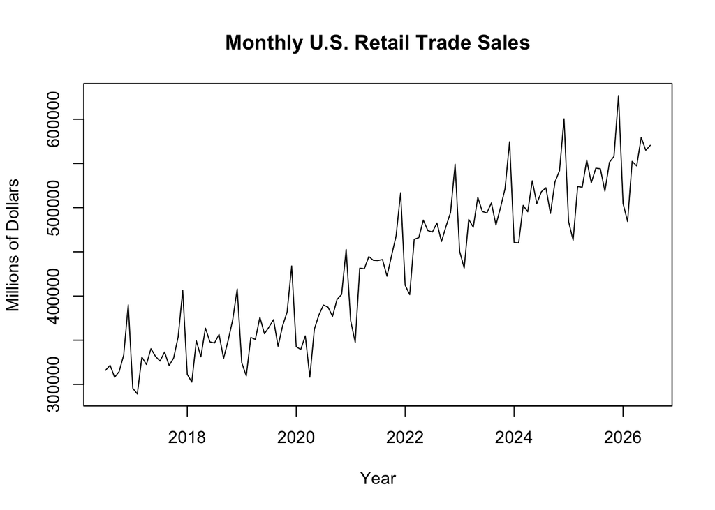

```r
plot(retail_ts,
     main = "Monthly U.S. Retail Trade Sales",
     xlab = "Year",
     ylab = "Millions of Dollars")
```

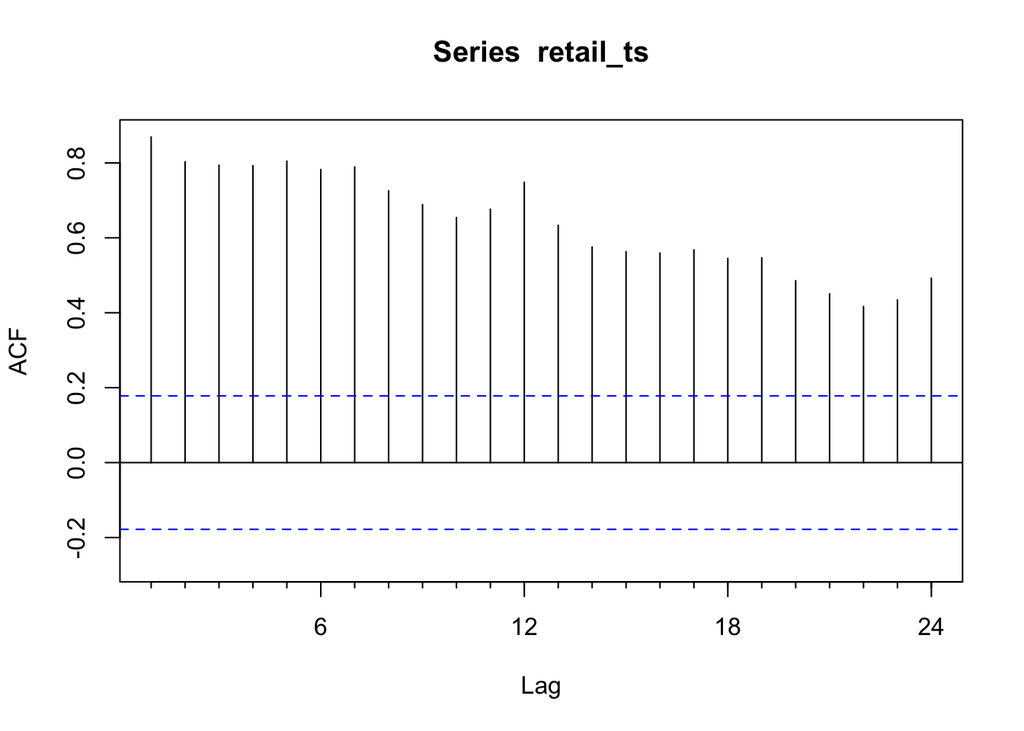

```r
Acf(retail_ts)
```

### Take Mean of all available history

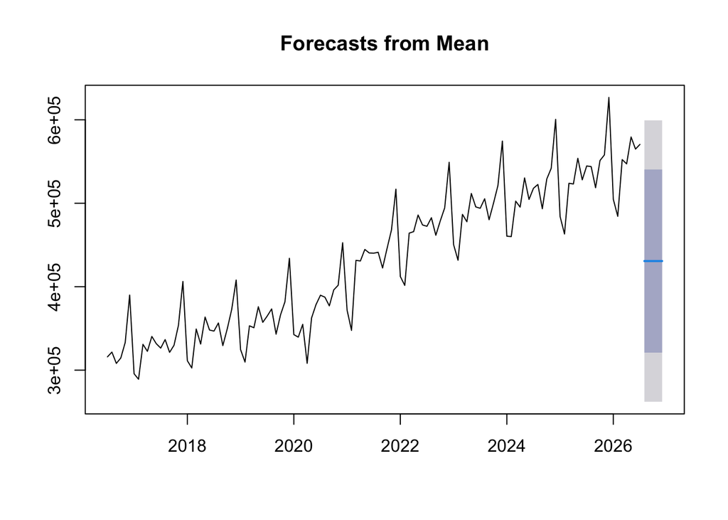

```r
mean_forecast <- meanf(retail_ts, 5)
plot(mean_forecast)
```

### The mean forecast uses the average of all historical retail sales as the forecast for future periods. Because the chart shows a clear upward trend, this model underestimates future sales and does not capture seasonality well.

# Naive Method

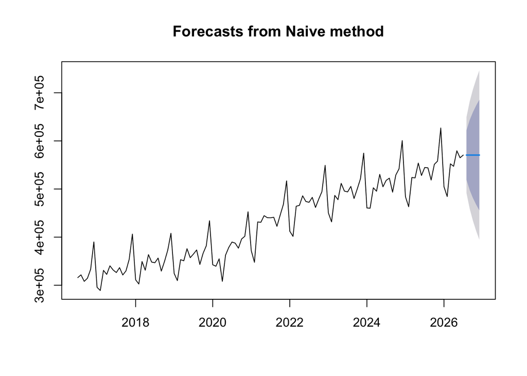

```r
naive_forecast <- naive(retail_ts,5)
plot(naive_forecast)
```

### The naive model uses the most recent observed value as the forecast for all future periods. It follows the latest sales level but does not include trend or recurring seasonal patterns.

# Random Walk

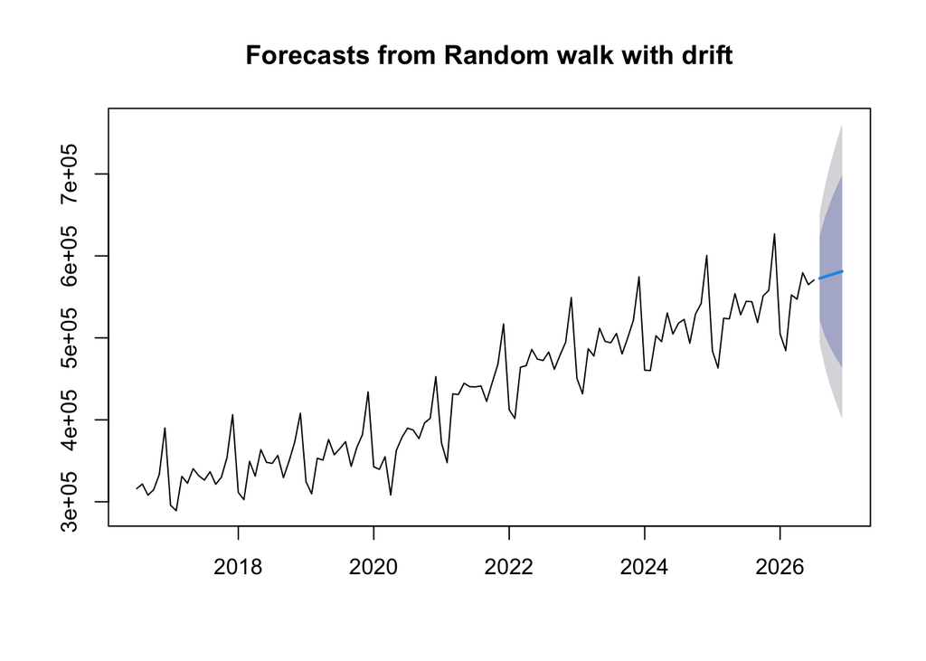

```r
rwf_forecast <- rwf(retail_ts,5, drift=TRUE)
plot(rwf_forecast)
```

### This model starts from the most recent value and extends the overall historical trend forward. The forecast increases over time, but it doesn’t consider the seasonal ups and downs in the retail data.

# Seasonal Naive

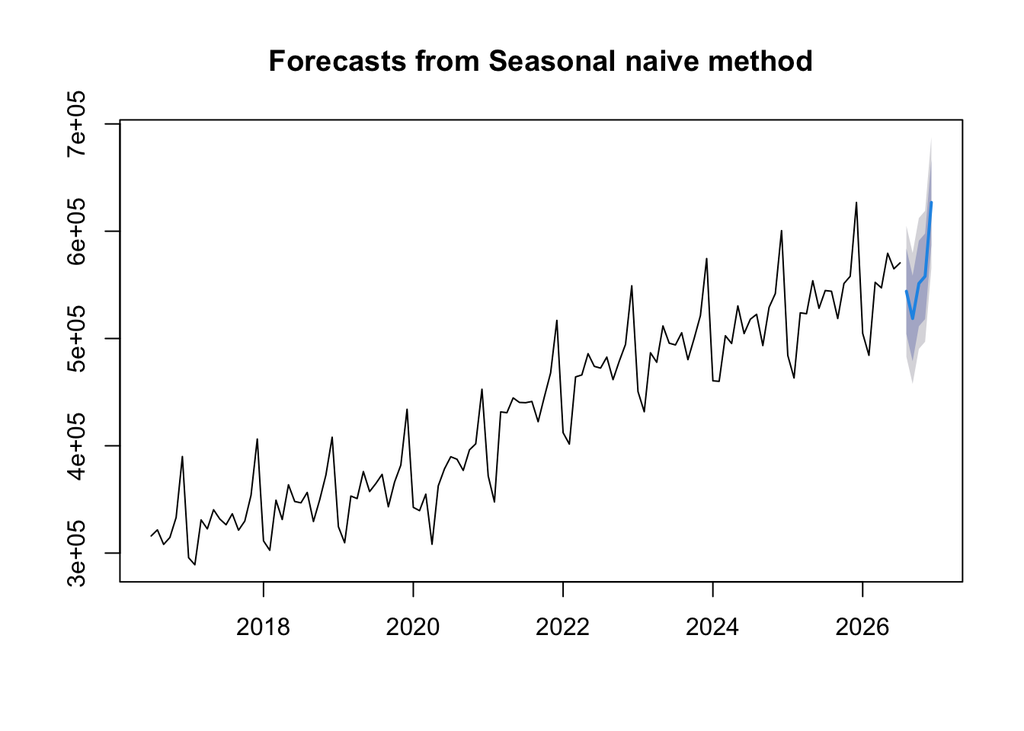

```r
snaive_forecast <- snaive(retail_ts,5)
plot(snaive_forecast)
```

### The seasonal naive model uses the value from the same period in the previous year to forecast each future month. This allows it to recreate the seasonal pattern shown in the retail sales data.

# Moving Averages

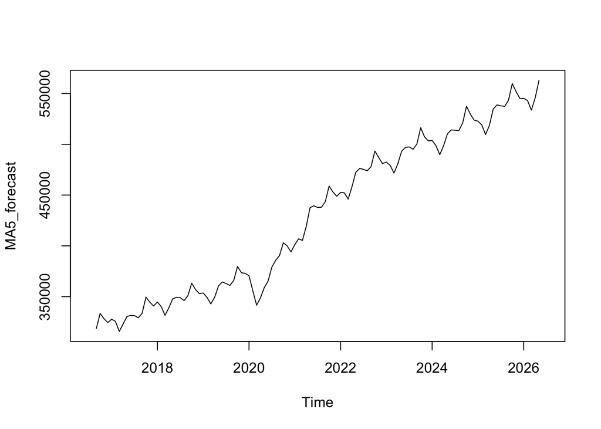

```r
MA5_forecast <- ma(retail_ts,order=5)
plot(MA5_forecast)
```

### The 5-period moving average smooths the retail sales data using the most recent five observations. It follows changes in the series more quickly and reduces short-term fluctuations while still showing the overall upward trend.

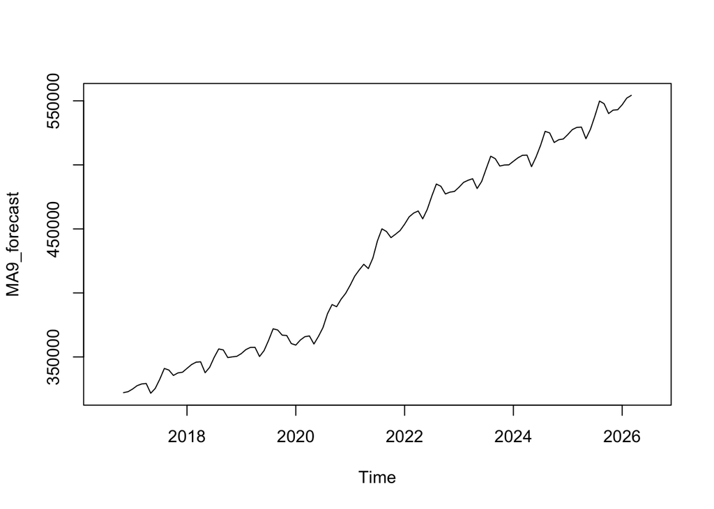

```r
MA9_forecast <- ma(retail_ts,order=9)
plot(MA9_forecast)
```

### The 9-period moving average uses a larger window, so the series is smoother than MA(5). It shows the long-term upward trend more clearly but reacts more slowly to sudden changes.

# Decomposition

```r
ets_forecast <- ets(retail_ts)
ets_forecast
```

```
## ETS(A,A,A)
##
## Call:
## ets(y = retail_ts)
##
##   Smoothing parameters:
##     alpha = 0.5447
##     beta  = 1e-04
##     gamma = 1e-04
##
##   Initial states:
##     l = 313903.6158
##     b = 1721.8827
##     s = 677.5641 15106.25 -11988.49 213.4388 -48010.95 -34932.62
##            67328.02 16788.96 2556.881 -16900.16 6922.487 2238.628
##
##   sigma:  10625.71
##
##      AIC     AICc      BIC
## 2840.719 2846.661 2888.247
```

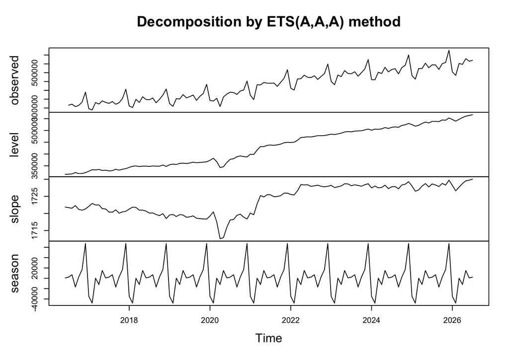

```r
plot(ets_forecast)
```

```r
attributes(ets_forecast)
```

```
## $names
##  [1] "loglik"     "aic"        "bic"        "aicc"       "mse"
##  [6] "amse"       "fit"        "residuals"  "fitted"     "states"
## [11] "par"        "m"          "method"     "series"     "components"
## [16] "call"       "initstate"  "sigma2"     "x"
##
## $class
## [1] "fc_model" "ets"
```

```r
ets_forecast$mse
```

```
## [1] 97976117
```

### The ETS model selected an additive error, additive trend, and additive seasonality trend. The decomposition shows that retail sales have a rising level, a positive trend, and a repeating seasonal pattern.

# HoltWinters

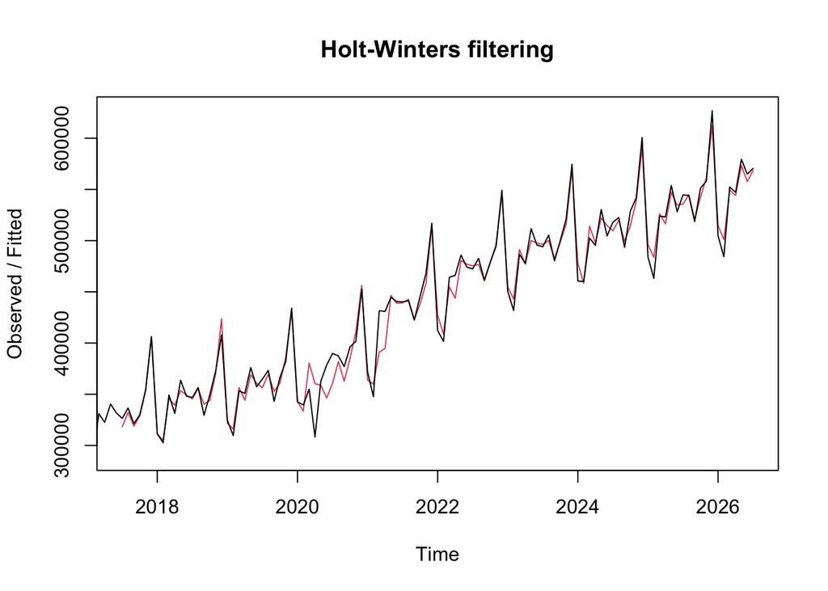

```r
HW_forecast <- HoltWinters(retail_ts)
plot(HW_forecast)
```

```r
HW_model <- HoltWinters(retail_ts)
HW_forecast <- forecast(HW_model, h = 5)
SSE_Simple <- HoltWinters(retail_ts,beta=FALSE,gamma=FALSE)
attributes(SSE_Simple)
```

```
## $names
## [1] "fitted"       "x"            "alpha"        "beta"         "gamma"
## [6] "coefficients" "seasonal"     "SSE"          "call"
##
## $class
## [1] "HoltWinters"
```

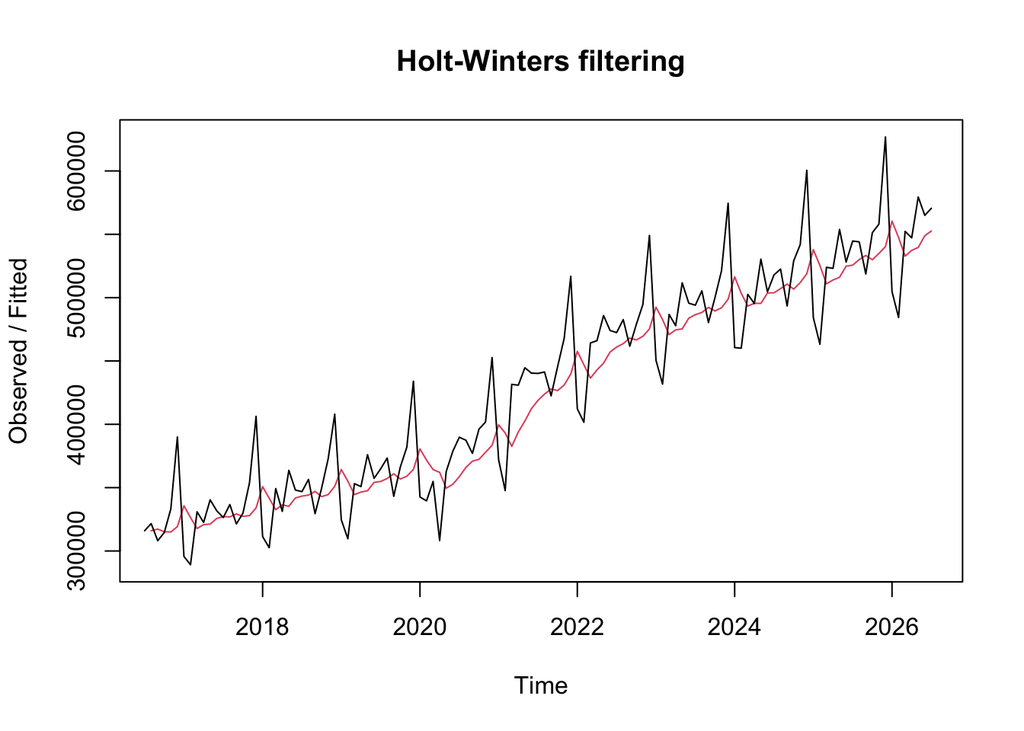

```r
plot(SSE_Simple)
```

```r
SSE_Simple$SSE
```

```
## [1] 135637693110
```

```r
head(SSE_Simple$fitted)
```

```
##              xhat    level
## Aug 2016 315969.0 315969.0
## Sep 2016 317288.7 317288.7
## Oct 2016 315150.2 315150.2
## Nov 2016 315011.2 315011.2
## Dec 2016 319243.6 319243.6
## Jan 2017 335712.7 335712.7
```

### The Holt-Winters model estimates the level, trend, and seasonal components of the retail sales series. The fitted values closely follow the observed values, showing that the model captures both the upward trend and recurring seasonal changes reasonably well.

# Plot all in a single chart

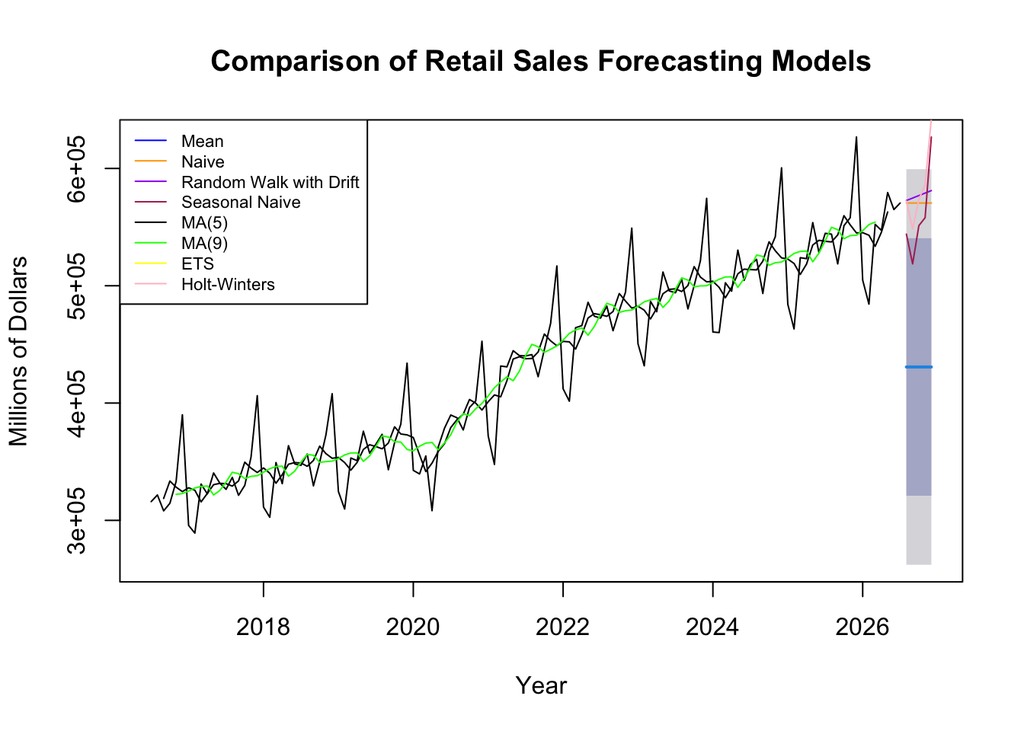

```r
plot(mean_forecast,
     main = "Comparison of Retail Sales Forecasting Models",
     xlab = "Year",
     ylab = "Millions of Dollars")

lines(naive_forecast$mean,col="orange")
lines(rwf_forecast$mean,col="purple")
lines(snaive_forecast$mean,col="maroon")
lines(MA5_forecast,col="black")
lines(MA9_forecast,col="green")
lines(ets_forecast$mean, col = "yellow")
lines(HW_forecast$mean, col = "pink")

legend("topleft",
       legend = c("Mean","Naive","Random Walk with Drift","Seasonal Naive","MA(5)","MA(9)",
                  "ETS","Holt-Winters"),
       col = c("blue","orange","purple","maroon","black","green","yellow","pink"),
       lty = 1,cex = 0.7)
```

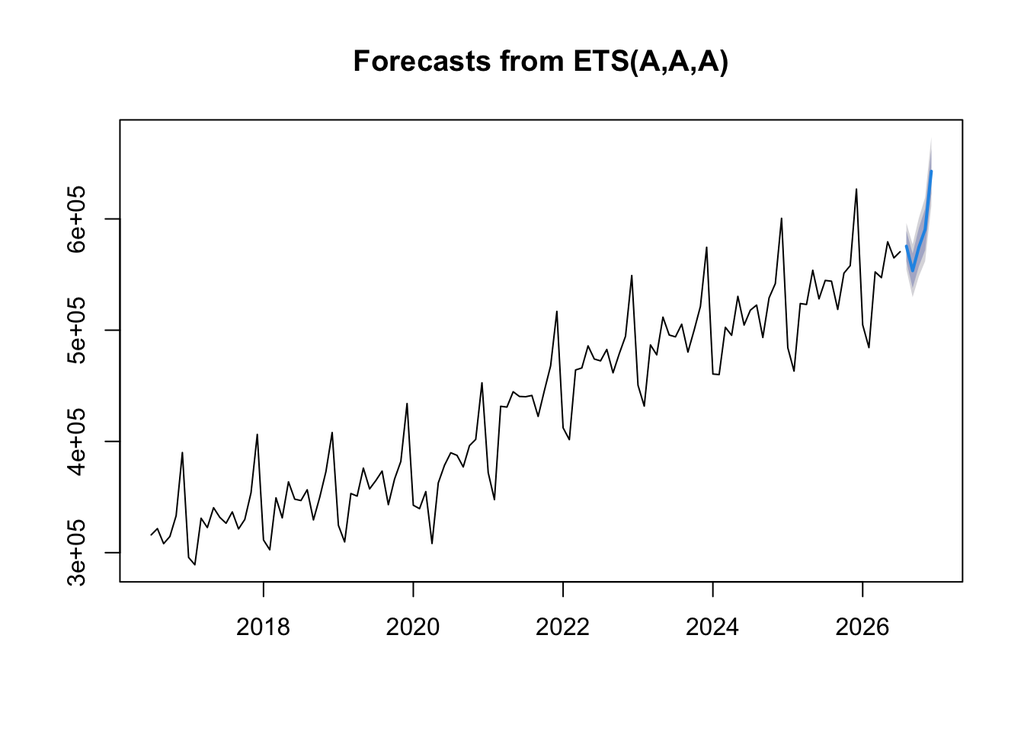

```r
forecast_ets_1 <- forecast.ets(ets_forecast, h=5)
plot(forecast_ets_1)
```

```r
forecast_ets_2 <- forecast(ets_forecast, h=5)
plot(forecast_ets_2)
```

[output not shown]

# Forecast Accuracy

```r
accuracy(mean_forecast)
```

```
##                        ME     RMSE      MAE       MPE     MAPE     MASE
## Training set 1.010216e-11 84458.39 74698.38 -4.002483 18.19068 2.887096
##                   ACF1
## Training set 0.8691853
```

```r
accuracy(naive_forecast)
```

```
##                    ME     RMSE      MAE        MPE  MAPE     MASE       ACF1
## Training set 2121.292 40115.08 28745.66 0.04688835 6.843 1.111021 -0.2856714
```

```r
accuracy(rwf_forecast)
```

```
##                         ME     RMSE      MAE        MPE     MAPE     MASE
## Training set -9.227582e-12 40058.95 28590.56 -0.4639511 6.826966 1.105026
##                    ACF1
## Training set -0.2856714
```

```r
accuracy(snaive_forecast)
```

```
##                    ME     RMSE      MAE     MPE    MAPE MASE      ACF1
## Training set 24847.25 31119.41 25873.19 5.54788 5.86879    1 0.7037624
```

```r
accuracy(ets_forecast)
```

```
##                    ME     RMSE      MAE        MPE     MAPE      MASE      ACF1
## Training set 672.9415 9898.289 6771.259 0.09698814 1.663844 0.2617094 0.1349248
```

```r
accuracy(HW_forecast)
```

```
##                    ME     RMSE     MAE       MPE     MAPE      MASE      ACF1
## Training set 1202.537 11389.55 7613.87 0.2053796 1.817304 0.2942764 0.2069961
```

# Choosing RMSE as the accuracy measure

```r
accuracy(mean_forecast)[1, "RMSE"]
```

```
## [1] 84458.39
```

```r
accuracy(naive_forecast)[1, "RMSE"]
```

```
## [1] 40115.08
```

```r
accuracy(rwf_forecast)[1, "RMSE"]
```

```
## [1] 40058.95
```

```r
accuracy(snaive_forecast)[1, "RMSE"]
```

```
## [1] 31119.41
```

```r
accuracy(ets_forecast)[1, "RMSE"]
```

```
## [1] 9898.289
```

```r
accuracy(HW_forecast)[1, "RMSE"]
```

```
## [1] 11389.55
```

### I chose to use RMSE to compare the accuracy of the forecasting models. A lower RMSE implies that the model’s predictions are generally closer to the actual observed values. Among all the models, the ETS model had the lowest RMSE of 9,898.29, Holt-Winters came in second with an RMSE of 11,389.55. Therefore, based on RMSE, ETS was the best-performing model for this retail sales time series.